# TP1_RodriguezAlejandro

Rodriguez Alejandro Edgar

2022-05-14

```r
theme <- theme(text = element_text(size=10),
               plot.title = element_text(size = 12, face = "bold.italic", hjust = 0.5),
               axis.title.x = element_text(size = 10, face="bold", colour='black'),
               axis.title.y = element_text(size = 10, face="bold"),
               panel.border = element_blank(),
               panel.grid.major = element_blank(),
               panel.grid.minor = element_blank(),
               legend.title = element_text(face="bold"))
```

# Trabajo Práctico N° 1

El trabajo práctico comenzó con la generación de una muestra aleatoria estratificada y balanceada por variedad de vino de tamaño n = 2000, utilizando como semilla los últimos tres dígitos de mi DNI (907). Para realizar el estratificado, se utilizo el comando group_by por variedad y luego con sample_n se seleccionaron 1000 datos de cada variedad, por lo que al tener 2 variedades (blanco y tinto), se obtuvo un total de 2000 datos.

## Importación de los datos

[Datos TP1](https://docs.google.com/spreadsheets/d/1iNNtiudSM-N1x7UQsO0T0fbRu-bNjMVZVYOmI1C9kcE)

```r
url_datos <- 'https://docs.google.com/spreadsheets/d/1iNNtiudSM-N1x7UQsO0T0fbRu-bNjMVZVYOmI1C9kcE'
datosTP1 = read.csv(text=gsheet2text(url_datos, format='csv'))
df_DatosTP1 = data.frame(datosTP1)
```

## Muestra aleatoria estratificada y balanceada

```r
# Seteo la semilla con los últimos 3 dígitos de mi documento
set.seed(907)

stratified_df = df_DatosTP1 %>%
  group_by(variedad) %>%
  sample_n(1000, replace=FALSE)

summary(stratified_df)
```

```
##   acidez.fija     acidez.volátil   ácido.cítrico  azúcar.residual
##  Min.   : 3.800   Min.   :0.0800   Min.   :0.00   Min.   : 0.700
##  1st Qu.: 6.600   1st Qu.:0.2600   1st Qu.:0.20   1st Qu.: 1.900
##  Median : 7.200   Median :0.3600   Median :0.30   Median : 2.400
##  Mean   : 7.578   Mean   :0.4076   Mean   :0.30   Mean   : 4.552
##  3rd Qu.: 8.200   3rd Qu.:0.5400   3rd Qu.:0.40   3rd Qu.: 5.825
##  Max.   :15.600   Max.   :1.5800   Max.   :1.23   Max.   :31.600
##     cloruros       anhídrido.sulfuroso.libre anhídrido.sulfuroso.total
##  Min.   :0.01200   Min.   :  1.00            Min.   :  6.00
##  1st Qu.:0.04300   1st Qu.: 12.00            1st Qu.: 37.00
##  Median :0.06000   Median : 22.00            Median : 89.00
##  Mean   :0.06777   Mean   : 25.42            Mean   : 91.96
##  3rd Qu.:0.08000   3rd Qu.: 35.00            3rd Qu.:137.00
##  Max.   :0.61100   Max.   :124.00            Max.   :294.00
##     densidad            pH           sulfatos         alcohol
##  Min.   :0.9872   Min.   :2.740   Min.   :0.2500   Min.   : 8.00
##  1st Qu.:0.9934   1st Qu.:3.140   1st Qu.:0.4600   1st Qu.: 9.50
##  Median :0.9959   Median :3.250   Median :0.5500   Median :10.20
##  Mean   :0.9954   Mean   :3.251   Mean   :0.5772   Mean   :10.45
##  3rd Qu.:0.9974   3rd Qu.:3.360   3rd Qu.:0.6500   3rd Qu.:11.20
##  Max.   :1.0103   Max.   :4.010   Max.   :1.9800   Max.   :14.00
##     calidad        variedad
##  Min.   :3.00   Min.   :1.0
##  1st Qu.:5.00   1st Qu.:1.0
##  Median :6.00   Median :1.5
##  Mean   :5.75   Mean   :1.5
##  3rd Qu.:6.00   3rd Qu.:2.0
##  Max.   :9.00   Max.   :2.0
```

```r
str(stratified_df)
```

```
## grouped_df [2,000 × 13] (S3: grouped_df/tbl_df/tbl/data.frame)
##  $ acidez.fija              : num [1:2000] 7.3 6.6 6.9 5.6 6.2 6.7 6 6.8 6.4 6.3 ...
##  $ acidez.volátil           : num [1:2000] 0.28 0.4 0.24 0.2 0.35 0.66 0.27 0.2 0.31 0.27 ...
##  $ ácido.cítrico            : num [1:2000] 0.43 0.46 0.23 0.66 0.03 0 0.32 0.28 0.26 0.25 ...
##  $ azúcar.residual          : num [1:2000] 1.7 6.2 7.1 10.2 1.2 13 3.6 12.6 13.2 5.8 ...
##  $ cloruros                 : num [1:2000] 0.08 0.056 0.041 0.043 0.064 0.033 0.035 0.048 0.046 0.038 ...
##  $ anhídrido.sulfuroso.libre: num [1:2000] 21 42 20 78 29 32 36 54 57 52 ...
##  $ anhídrido.sulfuroso.total: num [1:2000] 123 241 97 175 120 75 133 136 205 155 ...
##  $ densidad                 : num [1:2000] 0.991 0.997 0.992 0.995 0.993 ...
##  $ pH                       : num [1:2000] 3.19 3.5 3.1 2.98 3.22 3.15 3.23 3.19 3.17 3.28 ...
##  $ sulfatos                 : num [1:2000] 0.42 0.6 0.85 0.43 0.54 0.5 0.46 0.37 0.41 0.38 ...
##  $ alcohol                  : num [1:2000] 12.8 9.9 11.4 10.4 9.1 10.7 10.8 10.7 9.6 9.4 ...
##  $ calidad                  : int [1:2000] 5 5 6 7 5 6 6 6 5 6 ...
##  $ variedad                 : int [1:2000] 1 1 1 1 1 1 1 1 1 1 ...
##  - attr(*, "groups")= tibble [2 × 2] (S3: tbl_df/tbl/data.frame)
##   ..$ variedad: int [1:2] 1 2
##   ..$ .rows   : list<int> [1:2]
##   .. ..$ : int [1:1000] 1 2 3 4 5 6 7 8 9 10 ...
##   .. ..$ : int [1:1000] 1001 1002 1003 1004 1005 1006 1007 1008 1009 1010 ...
##   .. ..@ ptype: int(0)
##   ..- attr(*, ".drop")= logi TRUE
```

## Análisis estadístico de las variables por variedad

Una vez generado el data frame con el que vamos a trabajar, se procedió a realizar un análisis estadístico de cada una de las variables numéricas para cada variedad de vino. Para esto, se generó una lista con las variables numéricas, excluyendo calidad y variedad y luego se procesaron para obtener las siguientas medidas: cantidad de datos, mínimo, máximo, media, mediana, moda, varianza, desviación estándar, coeficiente de variación, cuartil 1, cuartil 3, rango intercuartílico, MAD, asimetría, curtosis.

Para la obtención de la moda, se realizó una función propia, donde se obtienen los valores únicos de la variable, se los ordena por frecuencia y se obtiene la que mayor frecuencia presenta.

```r
numeric_fields = c('acidez.fija','acidez.volátil','ácido.cítrico','azúcar.residual','cloruros','anhídrido.sulfuroso.libre','anhídrido.sulfuroso.total','densidad','pH','sulfatos','alcohol')

# Obtengo los subsets de cada variedad
variedad_blanco_df = stratified_df[stratified_df$variedad == 1,]
variedad_tinto_df = stratified_df[stratified_df$variedad == 2,]

# Función para obtener la moda de la variable
get_mode <- function(v) {
  uniqv = unique(v)
  count = table(v)
  mode = count[order(-count)][1]
  as.double(names(mode))
}

get_numeric_variables_attrs <- function(df, numeric_fields) {
  sd_df = apply(df, 2, sd)
  var_df = apply(df, 2, var)
  mad_df = apply(df, 2, mad)
  # https://es.acervolima.com/asimetria-y-curtosis-en-la-programacion-r/
  asimetria_df = apply(df,2, skewness)
  curtosis_df = apply(df,2, kurtosis)

  results = c()
  for (i in numeric_fields){
    columns = c("mode", "var", "sd", "mad", "asimetria", "curtosis")
    values = c(get_mode(df[i]), as.numeric(var_df[i]), as.numeric(sd_df[i]), as.numeric(mad_df[i]), as.numeric(asimetria_df[i]), as.numeric(curtosis_df[i]))

    # Aprovecho los valores que genera summary
    for (s in summary(df[i])) {
      splited = str_split(s, ":", simplify = TRUE)
      columns = c(columns, str_trim(splited[1,1]))
      values = c(values, as.double(str_trim(splited[1,2])))
    }

    results = rbind(results, values)
  }

  # Convierto la matriz a un data frame
  results_df = data.frame(results)

  # Asigno los nombres de las dimensiones al data frame resultante
  colnames(results_df) = columns
  rownames(results_df) = numeric_fields

  # Calculo las medidas dependientes de otros valores
  results_df$rango.intercuartil = results_df$`3rd Qu.` - results_df$`1st Qu.`
  results_df$coef.variacion = results_df$sd / results_df$Mean * 100

  results_df
}
```

### Resultados de la variedad 1 (blanco)

```r
# Calculo los valores para variedad 1 (blanco)
results_blanco_df = get_numeric_variables_attrs(variedad_blanco_df, numeric_fields)
results_blanco_df
```

|  | mode | var | sd | mad | asimetria | curtosis | Min. | 1st Qu. | Median | Mean | 3rd Qu. | Max. | rango.intercuartil | coef.variacion |
| --- | --- | --- | --- | --- | --- | --- | --- | --- | --- | --- | --- | --- | --- | --- |
| acidez.fija | 6.700 | 7.524952e-01 | 0.867464838 | 0.741300000 | 0.5030536 | 4.269629 | 3.8000 | 6.3000 | 6.8000 | 6.82200 | 7.3000 | 10.7000 | 1.0000 | 12.7156968 |
| acidez.volátil | 0.280 | 1.141466e-02 | 0.106839408 | 0.088956000 | 1.5330912 | 7.001118 | 0.0800 | 0.2100 | 0.2700 | 0.28380 | 0.3300 | 0.9300 | 0.1200 | 37.6460210 |
| ácido.cítrico | 0.300 | 1.611630e-02 | 0.126950004 | 0.088956000 | 1.4150601 | 8.374086 | 0.0000 | 0.2600 | 0.3100 | 0.33120 | 0.3800 | 1.2300 | 0.1200 | 38.3303151 |
| azúcar.residual | 1.200 | 2.746958e+01 | 5.241142750 | 5.485620000 | 0.8184111 | 2.891339 | 0.7000 | 1.7000 | 5.2000 | 6.53800 | 10.2250 | 31.6000 | 8.5250 | 80.1643125 |
| cloruros | 0.044 | 7.637288e-04 | 0.027635643 | 0.011860800 | 5.2626411 | 40.523769 | 0.0140 | 0.0350 | 0.0430 | 0.04734 | 0.0510 | 0.3460 | 0.0160 | 58.3769392 |
| anhídrido.sulfuroso.libre | 29.000 | 2.882762e+02 | 16.978697599 | 16.308600000 | 0.8910763 | 4.831788 | 3.0000 | 23.0000 | 34.0000 | 35.15000 | 45.0000 | 124.0000 | 22.0000 | 48.3035494 |
| anhídrido.sulfuroso.total | 128.000 | 1.764967e+03 | 42.011507742 | 43.736700000 | 0.2725234 | 2.856141 | 9.0000 | 107.0000 | 135.0000 | 138.20000 | 166.0000 | 294.0000 | 59.0000 | 30.3990649 |
| densidad | 0.993 | 9.212590e-06 | 0.003035225 | 0.003476697 | 0.3673539 | 2.855005 | 0.9872 | 0.9917 | 0.9938 | 0.99410 | 0.9964 | 1.0103 | 0.0047 | 0.3053239 |
| pH | 3.140 | 2.314489e-02 | 0.152134449 | 0.148260000 | 0.3880002 | 3.512321 | 2.7400 | 3.0980 | 3.1800 | 3.18900 | 3.2800 | 3.8000 | 0.1820 | 4.7706005 |
| sulfatos | 0.440 | 1.345013e-02 | 0.115974696 | 0.118608000 | 0.9379785 | 4.536958 | 0.2500 | 0.4000 | 0.4800 | 0.49100 | 0.5600 | 1.0600 | 0.1600 | 23.6201009 |

[output cut: 1 more lines]

```r
sum(is.na(results_blanco_df))
```

```
## [1] 0
```

### Resultados de la variedad 2 (tinto)

```r
# Calculo los valores para variedad 2 (tinto)
results_tinto_df = get_numeric_variables_attrs(variedad_tinto_df, numeric_fields)
results_tinto_df
```

|  | mode | var | sd | mad | asimetria | curtosis | Min. | 1st Qu. | Median | Mean | 3rd Qu. | Max. | rango.intercuartil | coef.variacion |
| --- | --- | --- | --- | --- | --- | --- | --- | --- | --- | --- | --- | --- | --- | --- |
| acidez.fija | 7.2000 | 2.976053e+00 | 1.725123964 | 1.40847000 | 0.94747875 | 3.912503 | 4.7000 | 7.1000 | 7.9500 | 8.33400 | 9.3000 | 15.6000 | 2.2000 | 20.6998316 |
| acidez.volátil | 0.6000 | 3.403700e-02 | 0.184491205 | 0.17791200 | 0.79566679 | 4.667683 | 0.1200 | 0.4000 | 0.5200 | 0.53140 | 0.6400 | 1.5800 | 0.2400 | 34.7179536 |
| ácido.cítrico | 0.0000 | 3.851798e-02 | 0.196259969 | 0.25204200 | 0.32746017 | 2.161597 | 0.0000 | 0.0900 | 0.2500 | 0.26870 | 0.4225 | 0.7900 | 0.3325 | 73.0405543 |
| azúcar.residual | 2.0000 | 2.022673e+00 | 1.422206936 | 0.44478000 | 4.30608170 | 28.632069 | 0.9000 | 1.9000 | 2.2000 | 2.56600 | 2.6000 | 15.5000 | 0.7000 | 55.4250560 |
| cloruros | 0.0800 | 2.278910e-03 | 0.047737932 | 0.01482600 | 5.37933429 | 40.312726 | 0.0120 | 0.0710 | 0.0790 | 0.08819 | 0.0900 | 0.6110 | 0.0190 | 54.1307772 |
| anhídrido.sulfuroso.libre | 6.0000 | 1.089918e+02 | 10.439912393 | 8.89560000 | 1.39523990 | 5.795796 | 1.0000 | 7.0000 | 13.0000 | 15.69000 | 21.0000 | 72.0000 | 14.0000 | 66.5386386 |
| anhídrido.sulfuroso.total | 28.0000 | 9.844192e+02 | 31.375455039 | 26.68680000 | 1.20683547 | 4.080816 | 6.0000 | 22.0000 | 37.5000 | 45.73000 | 62.0000 | 165.0000 | 40.0000 | 68.6102231 |
| densidad | 0.9976 | 3.372988e-06 | 0.001836569 | 0.00163086 | 0.07110718 | 3.842551 | 0.9901 | 0.9957 | 0.9968 | 0.99680 | 0.9979 | 1.0032 | 0.0022 | 0.1842465 |
| pH | 3.2600 | 2.256737e-02 | 0.150224414 | 0.13343400 | 0.19897319 | 4.185465 | 2.8600 | 3.2200 | 3.3100 | 3.31300 | 3.4000 | 4.0100 | 0.1800 | 4.5343922 |
| sulfatos | 0.6000 | 2.990809e-02 | 0.172939543 | 0.11860800 | 2.24050502 | 12.545983 | 0.3300 | 0.5500 | 0.6200 | 0.66330 | 0.7300 | 1.9800 | 0.1800 | 26.0725981 |

[output cut: 1 more lines]

```r
sum(is.na(results_tinto_df))
```

```
## [1] 0
```

## Análisis gráfico de las variables

### Calidad por variedad de vino

```r
mosaicplot(table(stratified_df$calidad,stratified_df$variedad),col=terrain.colors(7:11),main="Calidad de vinos por variedad",ylab="Variedad (blanco 1 / tinto 2)",xlab="Calidad (0 - muy malo y 10 - excelente)")
```

[output not shown]

### Alcohol

Se utilizaron boxplots para observar el comportamiento de las graduaciones de alcohol, tanto por variedad como por calidad. Comparando las distribuciones por variedad, se observan posibles outliers en los vinos tintos, pero no se observa una diferencia significativa en las medias y varianzas. En cambio, al comparar la distribución por calidad, se observa un aumento considerable en las medias a medida que la calidad aumenta, principalmente en los vinos de calidad media/alta.

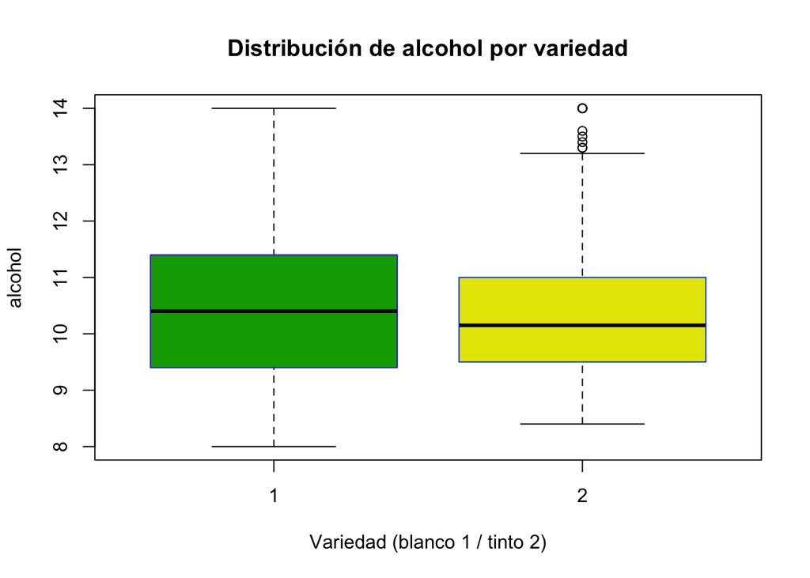

```r
with(stratified_df,boxplot(alcohol~variedad,boxcol=topo.colors(5),col=terrain.colors(5),main="Distribución de alcohol por variedad",xlab="Variedad (blanco 1 / tinto 2)"))
```

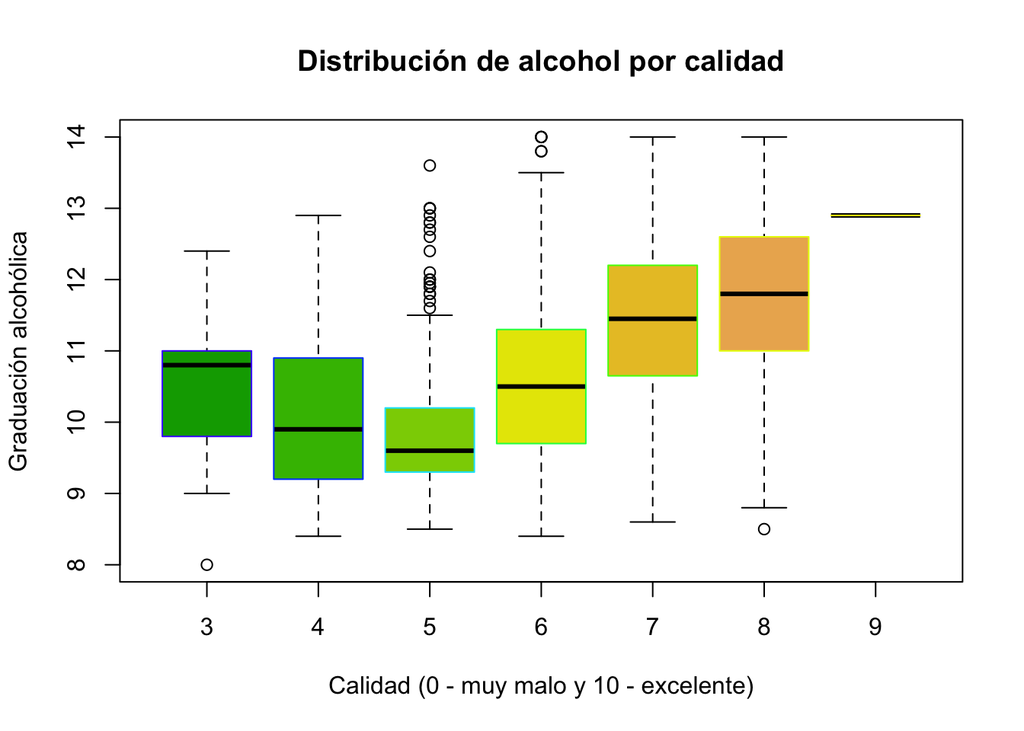

```r
with(stratified_df,boxplot(alcohol~calidad,boxcol=topo.colors(9),col=terrain.colors(9),main="Distribución de alcohol por calidad",xlab="Calidad (0 - muy malo y 10 - excelente)",ylab="Graduación alcohólica"))
```

### Azúcar residual

Se utilizó un boxplot para observar la concentración de azúcar residual entre la variedad de vinos blancos y tintos, esperando observar valores más altos en los vinos blancos, que suelen tener la característica de ser vinos dulces y se obtuvieron resultados acordes a lo esperado. Se observa una media y valores mucho más altos. En cambio, para los vinos tintos, parecen ser valors atípicos e incluso outliers.

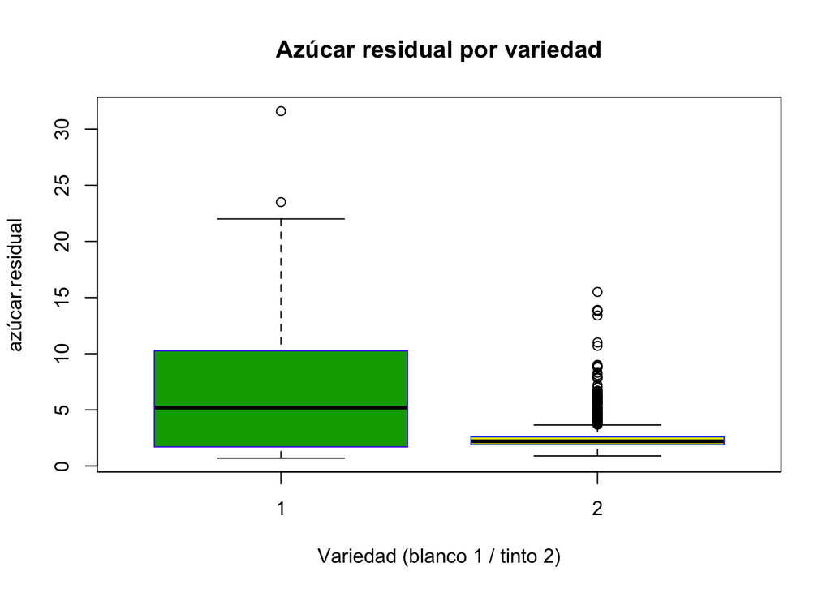

```r
with(stratified_df,boxplot(azúcar.residual~variedad,boxcol=topo.colors(5),col=terrain.colors(5),main="Azúcar residual por variedad",xlab="Variedad (blanco 1 / tinto 2)"),ylab="Azúcar residual")
```

### pH

Se utilizó un histograma para ver la distribución de los valores del pH. Al ser una variable continua y de rango acotado, se intentó verificar si la distribución tiene una forma reconocible. En este caso parecen dibujar una distribución normal, con media 3.25

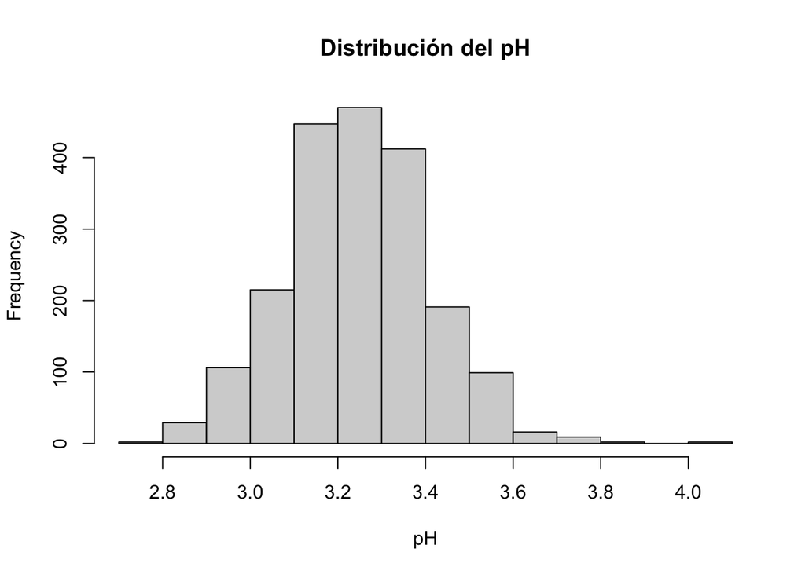

```r
hist(stratified_df$pH, main="Distribución del pH", xlab="pH")
```

### Densidad

Para la densidad, se tomó el mismo criterio que para el pH. En este caso se observa que la distribución tiene asímetria a izquierda.

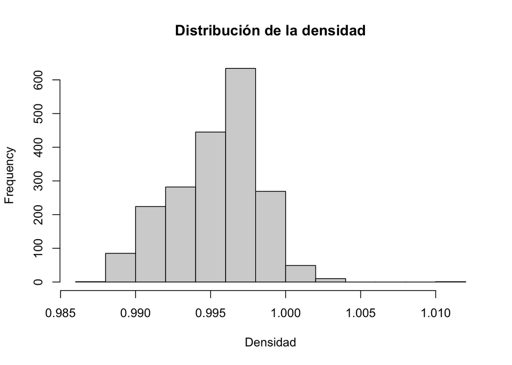

```r
hist(stratified_df$densidad, main="Distribución de la densidad", xlab="Densidad")
```

### Cloruros

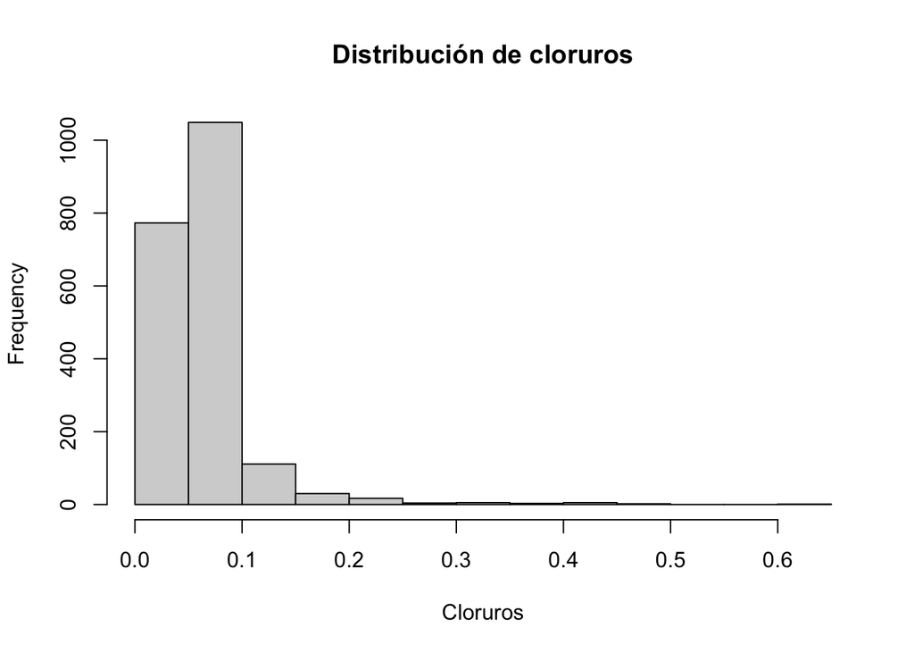

```r
hist(stratified_df$cloruros, main="Distribución de cloruros", xlab="Cloruros")
```

### Anhídrido sulfuroso

Para este caso, se graficaron 2 variables, ya que se intentó visualizar la relación entre el anhídrido sulfuroso libre y total, para ver si existe una diferencia notable. Si bien ambas variables parten del mismo elemento, la variable libre tiene valores mucho más concentrados y bajos, mientras que la total muestra un rango más amplio y pocos valores fuera del rango intercuartil.

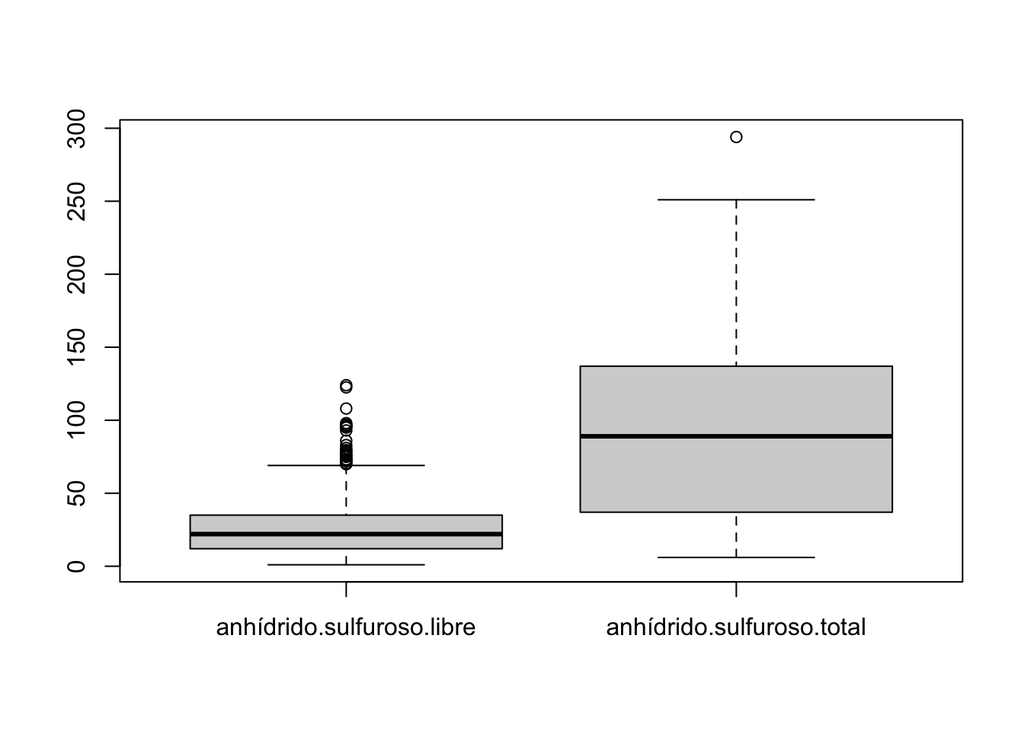

```r
boxplot(stratified_df[c('anhídrido.sulfuroso.libre','anhídrido.sulfuroso.total')])
```

### Acidez

En el primer gráfico se compara la distribución de la acidez fija y la volátil, observando valores muy diferentes, sin embargo, al compararlos por variedad, se observa que tienen un comportamiento similar.

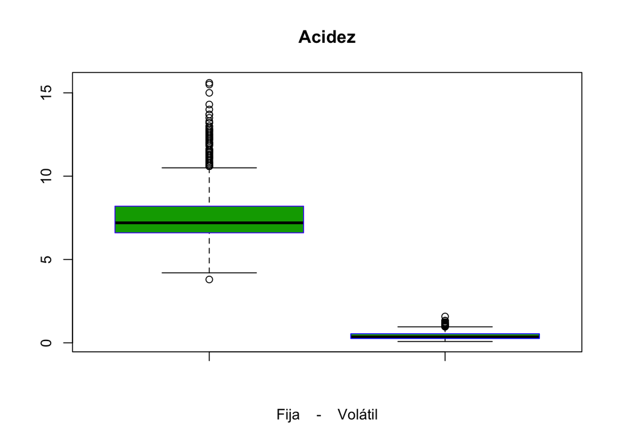

```r
with(stratified_df,boxplot(acidez.fija,acidez.volátil,boxcol=topo.colors(10),col=terrain.colors(10),main="Acidez",xlab="Fija    -    Volátil"))
```

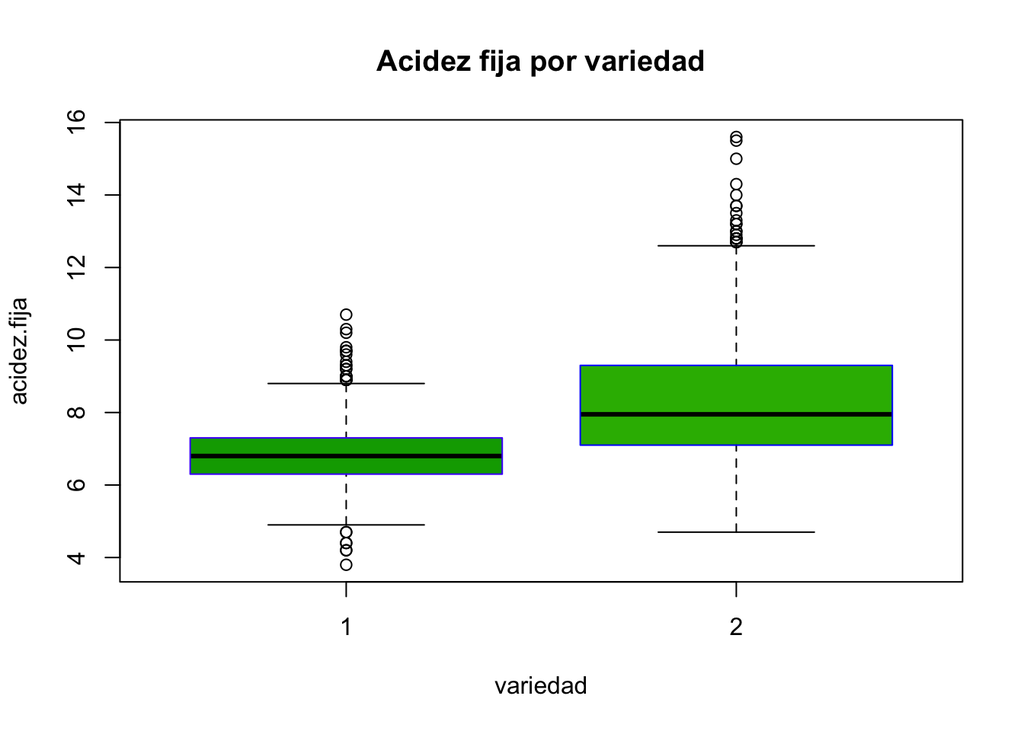

```r
with(stratified_df,boxplot(acidez.fija~variedad,boxcol=topo.colors(10),col=terrain.colors(10),main="Acidez fija por variedad"))
```

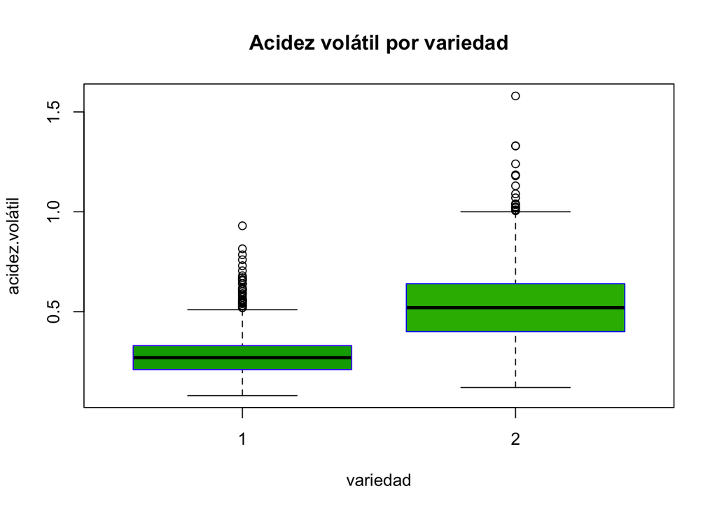

```r
with(stratified_df,boxplot(acidez.volátil~variedad,boxcol=topo.colors(10),col=terrain.colors(10),main="Acidez volátil por variedad"))
```

### Ácido cítrico

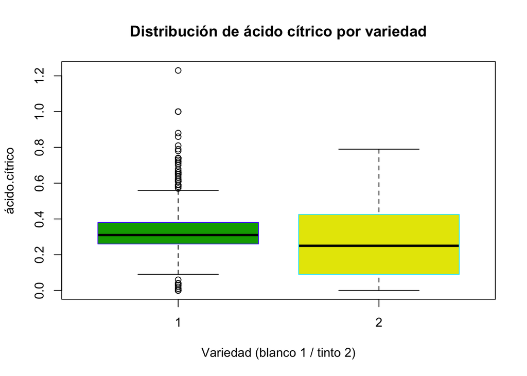

```r
with(stratified_df,boxplot(ácido.cítrico~variedad,boxcol=topo.colors(4),col=terrain.colors(4),main="Distribución de ácido cítrico por variedad",xlab="Variedad (blanco 1 / tinto 2)"))
```

## Análisis de la relación entre la calidad y la variedad

### Tabla de frecuencia

```r
frec.variedad.calidad = table(stratified_df$variedad,stratified_df$calidad)
frec.variedad.calidad
```

```
##
##       3   4   5   6   7   8   9
##   1   5  43 276 469 160  46   1
##   2   5  35 434 395 120  11   0
```

### Distribución

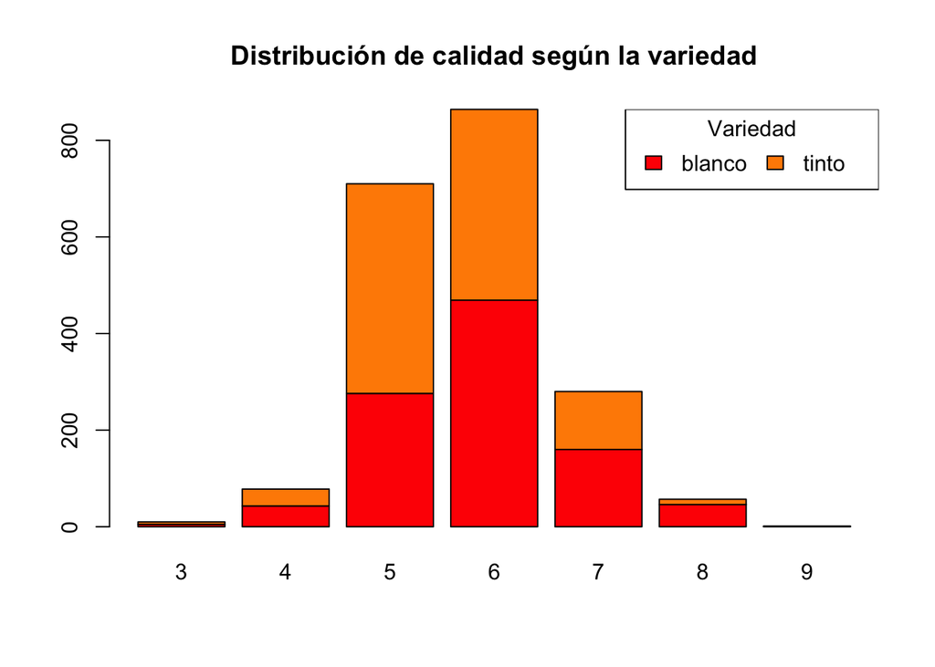

```r
barplot(table(stratified_df$variedad,stratified_df$calidad),col=rainbow(11),main="Distribución de calidad según la variedad")
legend("topright",cex=1,title="Variedad",c("blanco","tinto"),fill=rainbow(11),horiz=T)
```

```r
mosaicplot(table(stratified_df$calidad,stratified_df$variedad),col=terrain.colors(7:11),main="Calidad de vinos por variedad",ylab="Variedad (blanco 1 / tinto 2)",xlab="Calidad (0 - muy malo y 10 - excelente)")
```

[output not shown]

### Proporciones

[figure not shown]

```r
interior<-stratified_df%>%group_by(.dots=c("calidad"))%>%tally( )%>%mutate(porcent_abs=round(n/sum(n)*100,2)) # Produce tabla del sector interior

exterior<-stratified_df%>%group_by(.dots=c("calidad","variedad"))%>%
  tally( )%>%mutate(porcent_rel=round(n/sum(n)*100,2))%>%
  ungroup( )%>%
  mutate(porcent_abs=round(n/sum(n)*100,2))# Produce tabla del sector exterior
porcent_abs_ext=exterior$porcent_abs
tabla=table(exterior$calidad)[order(unique(exterior$calidad))]

#Establece los colores
colores=c("palegreen4","paleturquoise4","palevioletred4","salmon3")
col_int=rep_len(colores,length(stratified_df$calidad))
col_ext=lapply(Map(rep,colores[seq_along(tabla)],tabla),
               function(porcent_abs_ext){
                 al<-head(seq(0,1,length.out=length(porcent_abs_ext)+2L)[-1L],-1L)
                 Vectorize(adjustcolor)(porcent_abs_ext,alpha.f=al) } )

# Borra gráficos anteriores
plot.new()

# Produce los diagramas de tortas
torta_ext= floating.pie(0.5,0.5,exterior$porcent_abs , radius =0.25 ,
                        border="gray45" , col= unlist(col_ext))
torta_int= floating.pie( 0.5,0.5,interior$porcent_abs , radius =0.2 ,
                         border="white" , col=col_int )
pie.labels( x =0.5 , y =0.5 , torta_ext , paste0 ( exterior$variedad, "\n" ,
                                                   exterior$calidad , " % - " ,exterior$n , " ind. " ) ,
            minangle =0.2 , radius =0.27 , cex =0.6 , font=1)
pie.labels( x =0.5 , y =0.5 , torta_int, paste0( interior$calidad,"\n" ,
                                                 interior$porcent_abs , " % - " , interior$n , " ind. " ) ,
            minangle =0.2 , radius =0.09 , cex =0.6 , font=1)
```

## Discretización de las variables pH y Azúcar residual

Se decidió utilizar las variables pH y azúcar residual para generar nuevas variables categóricas, ya que se encontró información relacionada a los valores y rangos esperados de fuentes especializadas en el tema.

### pH

> El pH de la mayoría de los vinos se encuentra en el intervalo de 2,8 a 4, lo que lógicamente recae en el lado ácido de la escala. Un vino con un pH de 2,8 es extremadamente ácido mientras que uno con un pH en torno a 4 es plano, carente de acidez.

[Info sobre pH](https://www.aprenderdevino.es/ph-y-vino/)

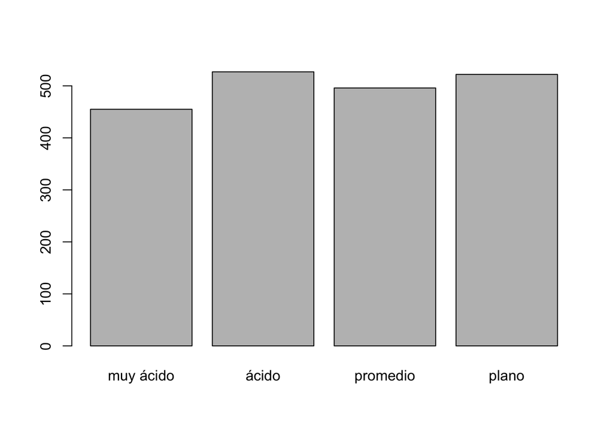

```r
disc.ph = discretize(stratified_df$pH, method = 'fixed', breaks = c(2.74,3.14,3.25,3.36,4.5), labels = c('muy ácido', 'ácido', 'promedio', 'plano'))
barplot(table(disc.ph))
```

### Azúcar residual

> Muy secos < 1 g/l de azúcar  
> Secos 1-5 g/l de azúcar  
> Semi-secos 5-15 g/l de azúcar  
> Abocados 15-30 g/l de azúcar  
> Dulces 30-120 g/l de azúcar  
> Muy dulces > 120 g/l de azúcar

[Info sobre azúcar residual](https://www.thegrandwines.com/2018/02/08/clasificaciones-del-vino/)

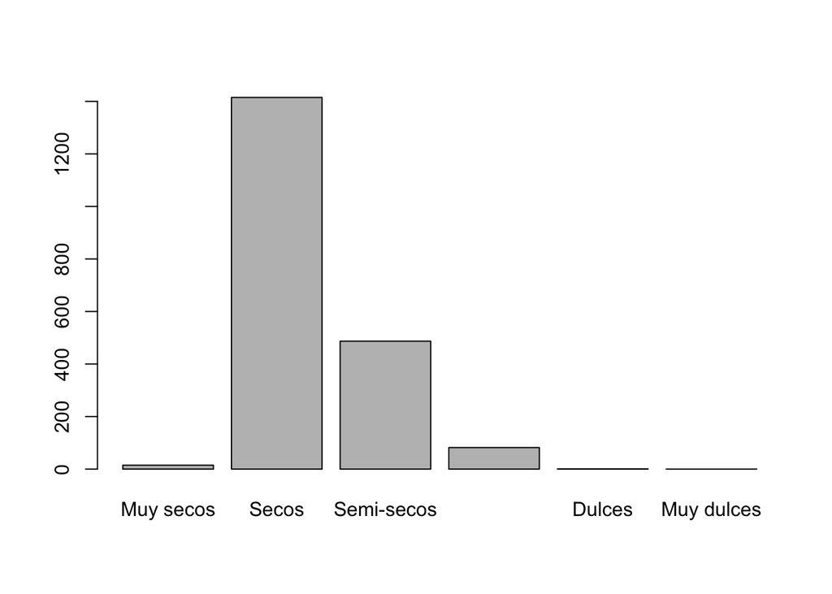

```r
disc.azucar = discretize(stratified_df$azúcar.residual, method = 'fixed', breaks = c(-Inf,1,5,15,30,120,+Inf), labels = c('Muy secos','Secos','Semi-secos','Abocados','Dulces','Muy dulces'))
barplot(table(disc.azucar))
```

### Asociación entre las variables

Con las categorías definidas se procede a realizar un test de independencia para identificar si existe alguna asociación. Para ello se utiliza el estadístivo Chi cuadrado con un nivel de significacia del 5%.

Se plantea:

H0: el valor de pH es independiente del nivel de azúcar residual.

H1: las variables no son independientes

```r
frec.azucar.ph = table(disc.azucar, disc.ph)
frec.azucar.ph
```

```
##             disc.ph
## disc.azucar  muy ácido ácido promedio plano
##   Muy secos          7     4        3     1
##   Secos            235   326      398   456
##   Semi-secos       173   170       83    61
##   Abocados          40    26       12     4
##   Dulces             0     1        0     0
##   Muy dulces         0     0        0     0
```

```r
test.independencia = chisq.test(frec.azucar.ph[1:4,])
test.independencia$p.value < 0.05
```

```
## [1] TRUE
```

El p-valor obtenido es menor a 0.05, por lo que se rechaza H0 y se puede afirmar con un alto grado de certeza que existe una asociación entre ambas variables.

## Diferencia de medias en ácido cítrico por variedad

Para el análisis de diferencias de medias, se optó por la variable ácido cítrico, ya que anteriormente, durante el análisis exploratorio, se observó que podría existir una diferencia significativa entre ambas variedades

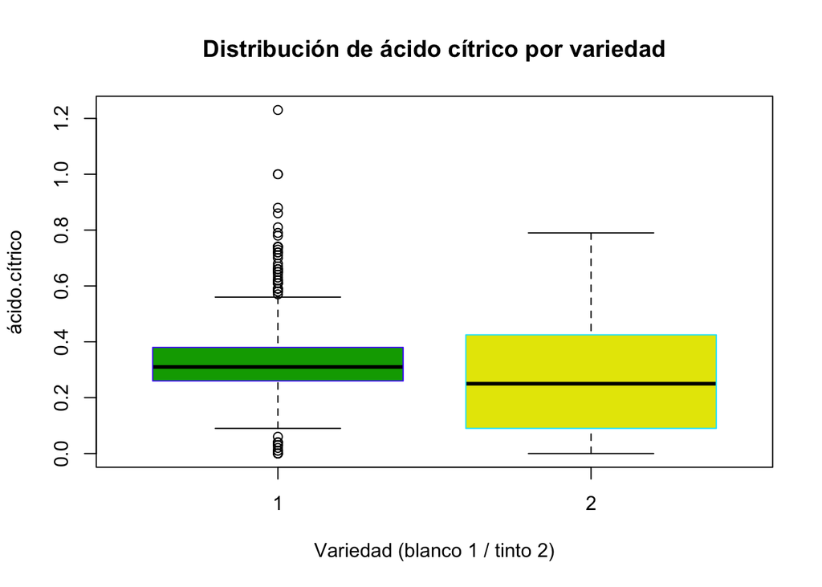

```r
with(stratified_df,boxplot(ácido.cítrico~variedad,boxcol=topo.colors(4),col=terrain.colors(4),main="Distribución de ácido cítrico por variedad",xlab="Variedad (blanco 1 / tinto 2)"))
```

Lo primero que realizamos fue el test de normalidad sobre las muestras para determinar si se cumplen con los supuestos y determinar cuál es el estadístico a aplicar

### Normalidad en variedad blanco

Obtenemos el subset de datos para la variedad 1 (vino blanco) y observamos su distribución

```r
acido.citrico.blanco = stratified_df[stratified_df$variedad == 1,]$ácido.cítrico
summary(acido.citrico.blanco)
```

```
##    Min. 1st Qu.  Median    Mean 3rd Qu.    Max.
##  0.0000  0.2600  0.3100  0.3312  0.3800  1.2300
```

Ejecutamos el test de Shapiro y evaluamos el p-valor. En este test H0 indica que los datos son normales.

```r
shapiro.test.acido.citrico.blanco = shapiro.test(acido.citrico.blanco)
shapiro.test.acido.citrico.blanco$p.value < 0.05
```

```
## [1] TRUE
```

Observamos que el p-valor es menor a 0.05, por lo cual rechazamos H0 y confirmamos que los datos no cumplen con el principio de normalidad.

### Normalidad en variedad tinto

```r
acido.citrico.tinto = stratified_df[stratified_df$variedad == 2,]$ácido.cítrico
summary(acido.citrico.tinto)
```

```
##    Min. 1st Qu.  Median    Mean 3rd Qu.    Max.
##  0.0000  0.0900  0.2500  0.2687  0.4225  0.7900
```

Corremos el test y evaluamos el p-valor.

```r
shapiro.test.acido.citrico.tinto = shapiro.test(acido.citrico.tinto)
shapiro.test.acido.citrico.tinto$p.value < 0.05
```

```
## [1] TRUE
```

En este caso, también comprobamos que no se cumple con el principio de normalidad

Ya que no se cumplen los supuestos de normalidad debemos optar por un test no paramétrico. En este caso aplicaremos Mann-Whitney-Wilcoxon, donde

$\theta_A$ a la mediana poblacional (posición central) del ácido cítrico de vino blanco.

$\theta_C$ a la mediana poblacional (posición central) del ácido cítrico de vino tinto.

Hipótesis

Ho $\theta_A = \theta_C$

Ha $\theta_A \neq \theta_C$

```r
wilcox.test.acido.citrico.result = wilcox.test(acido.citrico.blanco, acido.citrico.tinto, alternative = "two.sided")
wilcox.test.acido.citrico.result$p.value < 0.05
```

```
## [1] TRUE
```

Con el resultado del test, concluimos que rechazamos la hipótesis de la igualdad de las medianas de las dos variedades.

Adicionalmente, se probó con el test de medianas para corroborar el resultado de Mann-Whitney-Wilcoxon

```r
mood.medtest.acido.citrico.result =  mood.medtest(ácido.cítrico~variedad, data=stratified_df)
mood.medtest.acido.citrico.result$p.value < 0.05
```

```
## [1] TRUE
```

Con el resultado del test, corroboramos el rechazo de la hipótesis Ho de la igualdad de las medianas de las dos variedades.

## Análisis de la calidad respecto a las variedades

Empecemos viendo nuevamente los bloxplots de ambas variedades

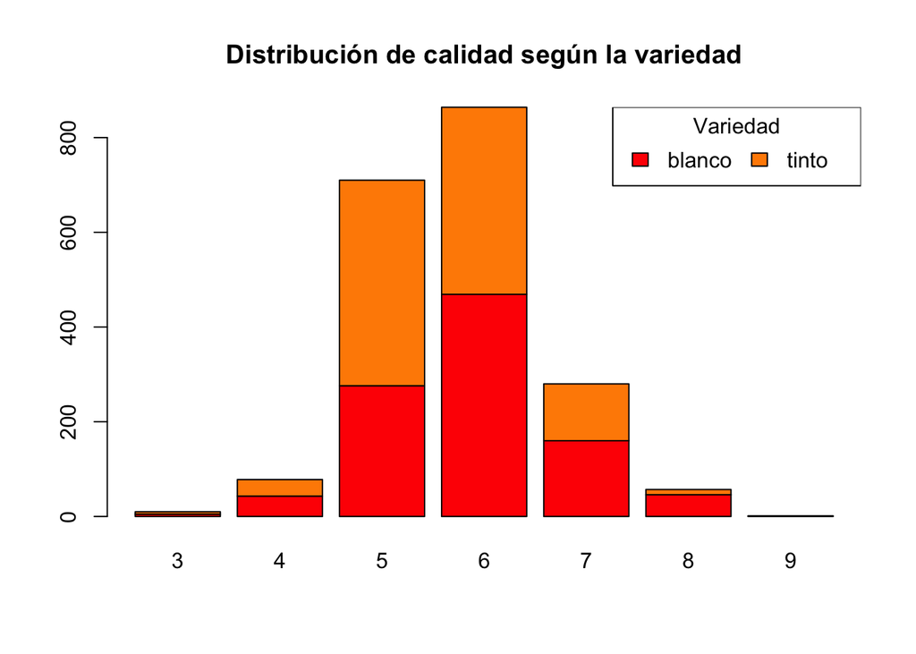

```r
barplot(table(stratified_df$variedad,stratified_df$calidad),col=rainbow(11),main="Distribución de calidad según la variedad")
legend("topright",cex=1,title="Variedad",c("blanco","tinto"),fill=rainbow(11),horiz=T)
```

```r
mosaicplot(table(stratified_df$calidad,stratified_df$variedad),col=terrain.colors(7:11),main="Calidad de vinos por variedad",ylab="Variedad (blanco 1 / tinto 2)",xlab="Calidad (0 - muy malo y 10 - excelente)")
```

[output not shown]

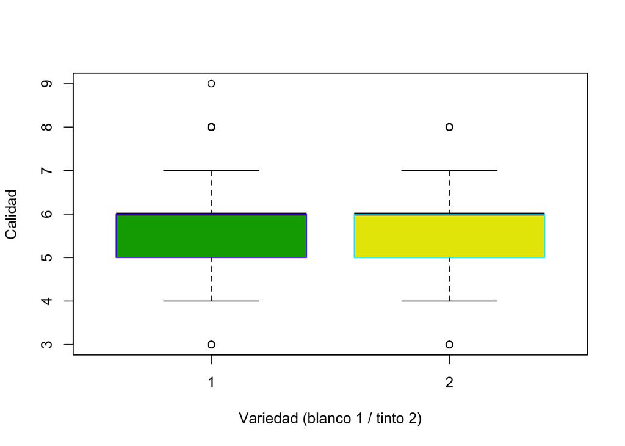

```r
boxplot(stratified_df$calidad~stratified_df$variedad, xlab="Variedad (blanco 1 / tinto 2)", ylab="Calidad",boxcol=topo.colors(4),col=terrain.colors(4))
```

A simple vista no parece haber diferencias, pero realizaremos una diferencia de medias para corroborar la hipótesis

Planteo la hipótesis:

Ho: $\mu_{blanco} - \mu_{tinto} \le 0$

Verifico los supuestos de normalidad:

```r
calidad.blanco = stratified_df[stratified_df$variedad == 1,]$calidad
shapiro.test.calidad.blanco = shapiro.test(calidad.blanco)
shapiro.test.calidad.blanco$p.value < 0.05
```

```
## [1] TRUE
```

```r
calidad.tinto = stratified_df[stratified_df$variedad == 2,]$calidad
shapiro.test.calidad.tinto = shapiro.test(calidad.tinto)
shapiro.test.calidad.tinto$p.value < 0.05
```

```
## [1] TRUE
```

Ninguna de las variables cumple con el prinicipio de normalidad, por lo que nuevamente recurrimos al test no paramétrico de Mann-Whitney-Wilcoxon

```r
wilcox.test.calidad.result = wilcox.test(x=calidad.blanco, y=calidad.tinto, alternative = "greater")
wilcox.test.calidad.result$p.value < 0.05
```

```
## [1] TRUE
```

## ANOVA: proporciones de alcohol en la calidad de los vinos

A continuación, realizaremos un análisis sobre la proporción de alcohol según la calidad del vino. Para ello generaremos 3 categorías para la calidad: baja, media y alta

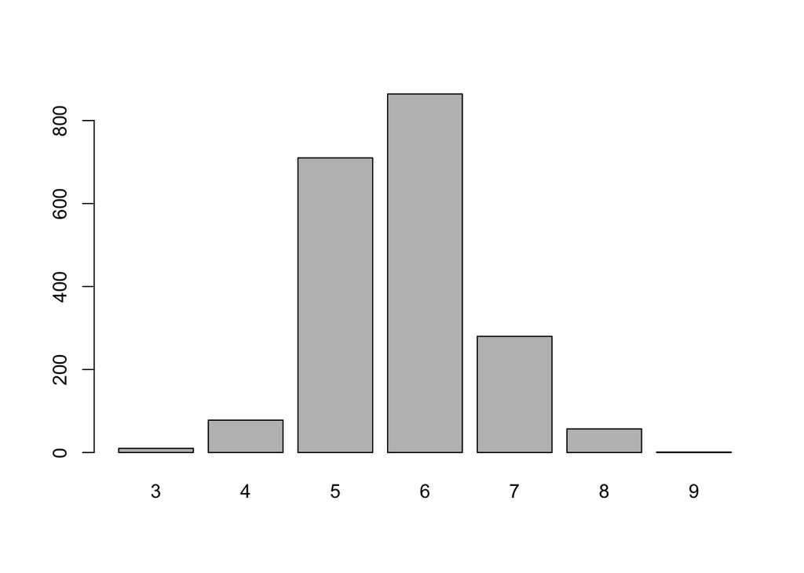

```r
barplot(table(stratified_df$calidad))
```

```r
stratified_df['calidad.disc'] = discretize(stratified_df$calidad, method = 'fixed', breaks = c(-Inf,5,7,+Inf), labels = c('Baja','Media','Alta'))
```

### Nueva variable categórica:

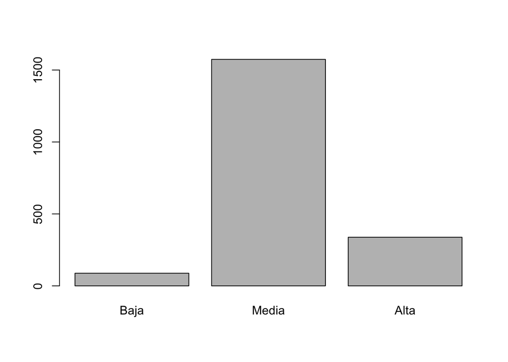

```r
barplot(table(stratified_df['calidad.disc']))
```

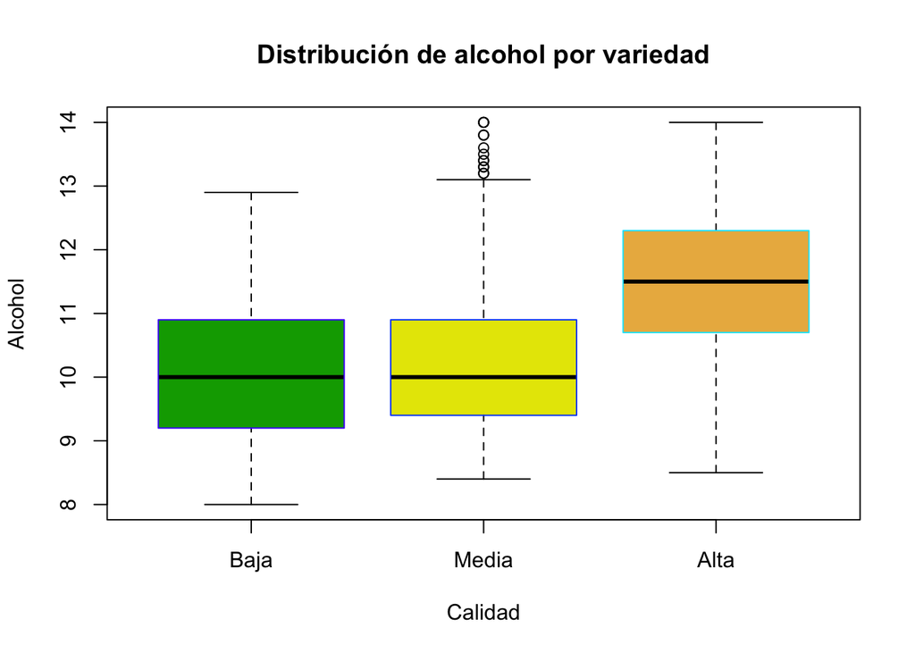

```r
with(stratified_df,boxplot(alcohol~calidad.disc,boxcol=topo.colors(5),col=terrain.colors(5),main="Distribución de alcohol por variedad",xlab="Calidad",ylab="Alcohol"))
```

### Test de ANOVA

Ejecutamos el test de ANOVA y observamos los resultados obtenidos, para luego analizar los residuos

```r
anova.alcohol.calidad = aov(alcohol ~ factor(calidad.disc), data=stratified_df)
summary(anova.alcohol.calidad)
```

```
##                        Df Sum Sq Mean Sq F value Pr(>F)
## factor(calidad.disc)    2  416.9  208.45   186.1 <2e-16 ***
## Residuals            1997 2237.3    1.12
## ---
## Signif. codes:  0 '***' 0.001 '**' 0.01 '*' 0.05 '.' 0.1 ' ' 1
```

```r
anova.alcohol.calidad
```

```
## Call:
##    aov(formula = alcohol ~ factor(calidad.disc), data = stratified_df)
##
## Terms:
##                 factor(calidad.disc) Residuals
## Sum of Squares              416.8981 2237.2945
## Deg. of Freedom                    2      1997
##
## Residual standard error: 1.058455
## Estimated effects may be unbalanced
```

### Supuestos

- Las muestras deben ser aleatorias y las observaciones independientes
- Las varianzas de las subpoblaciones deben ser iguales (homocedasticidad)
- La distribución de cada subpoblación es normal

#### Análisis de residuos

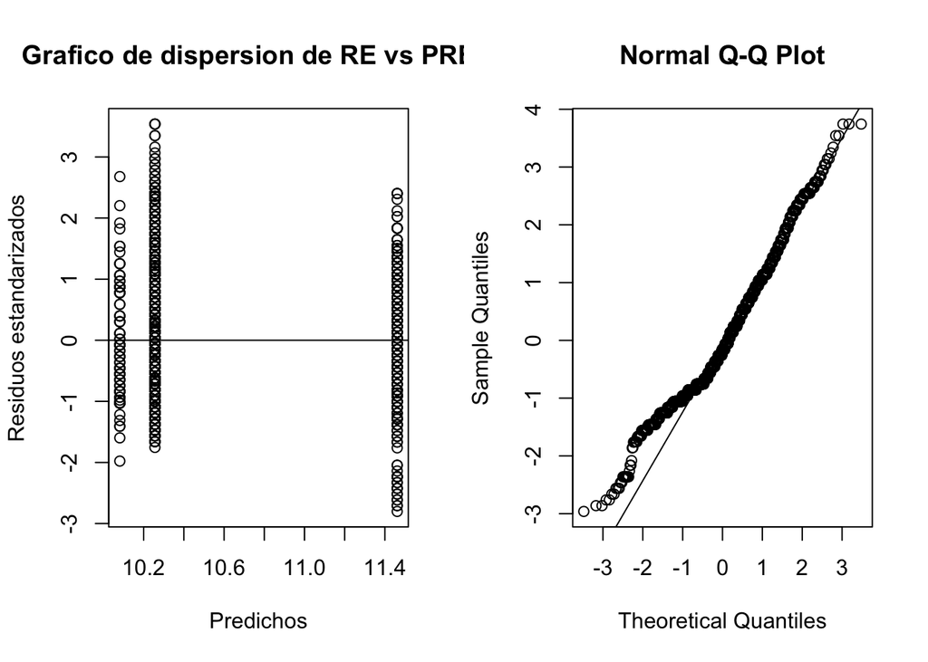

```r
e<-resid(anova.alcohol.calidad) # residuos
re<-rstandard(anova.alcohol.calidad) #residuos estandarizados
pre<-predict(anova.alcohol.calidad) #predichos
res<-cbind(stratified_df$calidad.disc,stratified_df$alcohol,pre,e,round(re,2))
colnames(res)<-c("Calidad Vino", "Alcohol", "Predichos", "Residuos", "residuos std")

res<-as.data.frame(res)
par(mfrow = c(1, 2))
plot(pre, re, xlab="Predichos", ylab="Residuos estandarizados",main="Grafico de dispersion de RE vs PRED" )
abline(0,0)
qqnorm(e)
qqline(e)
```

#### Normalidad de residuos Para determinar la normalidad de las variables, podemos analizar la normalidad de los residuos y obtener una conclusión de ahí

```r
shapiro.test.residuos = shapiro.test(e)
shapiro.test.residuos$p.value < 0.05
```

```
## [1] TRUE
```

```r
shapiro.test.residuos.std = shapiro.test(re)
shapiro.test.residuos.std$p.value < 0.05
```

```
## [1] TRUE
```

Rechazamos la normalidad de los alguna de las variables, por lo que el resultado de ANOVA no puede ser considerado como verdadero. Es necesario implementar un test no paramétrico y en este caso utilizaremos Kruscal-Wallis

#### Kruscal-Wallis

Planteamos las hipótesis:

Ho: Los tres grupos tienen la misma posición para la variable de estudio

Ha: al menos un grupo tiene diferente posición para la variable en estudio

Generamos las nuevas variables de estudio, alcohol según la categoría de calidad y ejecutamos el test

```r
alcohol.calidad.baja = stratified_df[stratified_df$calidad.disc=="Baja",]$alcohol
alcohol.calidad.media = stratified_df[stratified_df$calidad.disc=="Media",]$alcohol
alcohol.calidad.alta = stratified_df[stratified_df$calidad.disc=="Alta",]$alcohol

shapiro.test(alcohol.calidad.baja)
```

```
##
##  Shapiro-Wilk normality test
##
## data:  alcohol.calidad.baja
## W = 0.97037, p-value = 0.04123
```

```r
shapiro.test(alcohol.calidad.media)
```

```
##
##  Shapiro-Wilk normality test
##
## data:  alcohol.calidad.media
## W = 0.93967, p-value < 2.2e-16
```

```r
shapiro.test(alcohol.calidad.alta)
```

```
##
##  Shapiro-Wilk normality test
##
## data:  alcohol.calidad.alta
## W = 0.98326, p-value = 0.0005738
```

```r
kruskal.test(stratified_df$alcohol~stratified_df$calidad.disc)
```

```
##
##  Kruskal-Wallis rank sum test
##
## data:  stratified_df$alcohol by stratified_df$calidad.disc
## Kruskal-Wallis chi-squared = 275.75, df = 2, p-value < 2.2e-16
```

```r
kruskalmc(stratified_df$alcohol~stratified_df$calidad.disc)
```

```
## Multiple comparison test after Kruskal-Wallis
## p.value: 0.05
## Comparisons
##              obs.dif critical.dif difference
## Baja-Media  80.79523    151.43986      FALSE
## Baja-Alta  646.71500    165.45257       TRUE
## Media-Alta 565.91977     82.88036       TRUE
```

El resultado del test nos indica que se rechaza Ho, por lo tanto existe diferencia en las medias de las variables de estudio y adicionalmente podemos ver en donde se observan las diferencias. El test nos muestra que la diferencia se da entre los vinos de categoría alta y el resto.